# Our Glamorous Times - Analysis

# Reading text files

All files were encoded using UTF-8 (ASCII insufficient, plain Unicode somehow problematic).

```r
A <- readLines(con <- file("test_eng_utf.txt", encoding = "UTF-8"))

C <- readLines(con <- file("test_ch_utf.txt", encoding = "UTF-8"))

C1 <- readLines(con <- file("ch1.txt", encoding = "UTF-8"))

T <- readLines(con <- file("ogt_utf.txt", encoding = "UTF-8"))
```

## Displaying characters

Changing these settings allows viewing Chinese characters in the data frame viewer in RStudio.

```r
#Sys.setlocale(locale = "Chinese") #Choose Chinese
#Sys.setlocale() #Revert back to original when finished
```

# Most common words

```r
single_counts <- table(unlist(strsplit(T, split="")))

single_counts <- single_counts[order(single_counts, decreasing = TRUE)]
```

```r
single_counts[1:100]
```

```
   ，    。    的    一    了    他    是    不    她     2    在     0
21897 13729 12440  7482  6736  5669  4764  4412  4137  3941  3834  3806
   个     ”     “    这     :    林    人     1    浅    有    着    时
 3659  3537  3536  3408  3319  3224  3071  3041  2985  2931  2693  2633
   地    就    来    上     …    ：     -    看    也    到    厉     4
 2598  2440  2323  2285  2268  2262  2212  2122  2044  2040  2021  1996
   我    致    诚    间     —    下    ？    然    头    么    说    里
 1993  1929  1888  1727  1706  1683  1669  1616  1596  1593  1550  1540
   得    心    手    还    你    会    大    要          过    、    那
 1519  1484  1470  1388  1384  1376  1365  1352  1327  1325  1324  1323
   出    后    投    而    们    都     3    点    开    没    起    扔
 1279  1264  1247  1242  1222  1208  1204  1179  1153  1151  1132  1114
   掷    \t    好    身    天    想    很    雷    中    眼    子    去
 1104  1103  1096  1078  1073  1046  1039  1035  1034  1007  1005   996
   以    又    对    为    笑    面    可    只    自    意     5    声
  995   995   959   933   931   924   900   891   887   885   884   866
   明    话    经    前
  853   851   838   830
```

```r
saveRDS(single_counts, "single_counts.Rda")
```

# Most common pairs of words

## Method

Developing the tools

### A method for splitting vectors into pairs of words

https://stackoverflow.com/questions/2247045/chopping-a-string-into-a-vector-of-fixed-width-character-elements

```r
x <- "xxyyxyxy"
sst <- strsplit(x, "")[[1]]
paste0(sst[c(TRUE, FALSE)], sst[c(FALSE, TRUE)])
```

### Expanding the method to include all possible pairs

On good track, but repeats the final character (need to control the parity of the input)

```r
x <- "xxyyxyxy"
sst <- unlist(strsplit(x, ""))
sst <- sst[2:length(sst)]
paste0(sst[c(TRUE, FALSE)], sst[c(FALSE, TRUE)])
```

### Analysing required functionality

Case 1: Even characters  
Original string: KLMNOP  
Without first char: LMNOP  
First pass: KL, MN, OP  
Second pass: LM, NO, P(P)

Case 2: Odd characters  
Original string: ABCDEFG  
Without first char: BCDEFG  
First pass: AB, CD, EF, G(G)  
Second pass: BC, DE, FG

Case 3: Even plus .  
KLMNOP.  
LMNOP.  
KL, MN, OP, .(.)  
LM, NO, P.

case 4: Odd plus .  
ABCDEFG.  
BCDEFG.  
AB, CD, EF, G.  
BC, DE, FG, .(.)

For even numbers: remove last pair from the SECOND pass For odd numbers: remove last pair from the FIRST pass

### Function

```r
ch2split <- function(x){
  if (length(x)>1){
    stop("Vectors are not allowed")
  }
  if (nchar(x)!=0){
    x1 <- unlist(strsplit(x, split=""))
    x2 <- x1[-1] #Need to take empty vectors into account

    w1 <- paste0(x1[c(TRUE, FALSE)], x1[c(FALSE, TRUE)])
    w2 <- paste0(x2[c(TRUE, FALSE)], x2[c(FALSE, TRUE)])

    if(length(x1)%%2==1){
      w1 <- w1[1:length(w1)-1]
    }

    if(length(x1)%%2==0){
      w2 <- w2[1:length(w2)-1]
    }

    #unwanted <- “，！…”

    unwanted <- "\\p{P}"

    w1 <- w1[!grepl(unwanted, w1, perl=TRUE)]
    w2 <- w2[!grepl(unwanted, w2, perl=TRUE)]
    return(c(w1,w2))
  } else {
    return("")
  }

}
```

## Basic case

### Workflow

```r
words <- sapply(T, ch2split)
names(words) <- NULL
words <- unlist(words)

words_counts <- table(words)
words_counts <- words_counts[order(words_counts, decreasing = TRUE)]

words_counts <- as.data.frame(words_counts)

#Remove unwanted entries
words_counts <- words_counts[!(words_counts$words==""),] #Empty strings
words_counts <- words_counts[!grepl("[[:alnum:]]", words_counts$words),] #Numbers and letters
```

### Save results

```r
saveRDS(words_counts, "words_counts.Rda")
```

### Visualisation

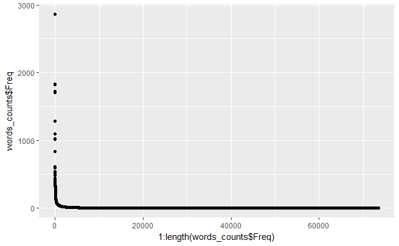

```r
#library(ggplot2)
qplot(y=words_counts$Freq, x=1:length(words_counts$Freq))
```

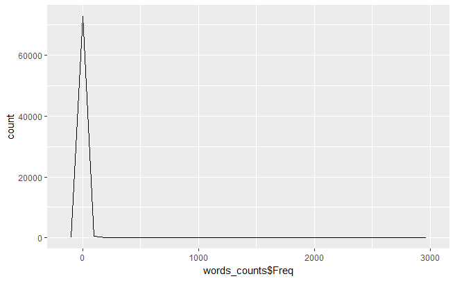

```r
library(ggplot2)
#Initial approaches
ggplot(words_counts, aes(x = words_counts$Freq)) + geom_freqpoly()
```

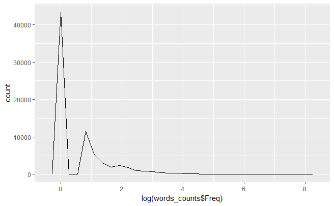

```r
ggplot(words_counts, aes(x = log(words_counts$Freq))) + geom_freqpoly() #Rather dodgy approach with log (should be log counts, not log frequency)
```

```r
#Best so far
ggplot(words_counts, aes(Freq)) +
geom_histogram(binwidth = 50) + scale_y_log10()
```

[output not shown]

## Excluding the top 100 commmonest characters

Rationale: words which do not contain top 100 characters are more likely to be actual words rather than frequent combinations of individual characters.

### weliminate() - Function for finding indices of interest

```r
weliminate <- function(elim, x){
  #To include some statements to prevent the possibility of input (x) being a matrix/df
  y <- replicate(length(x), TRUE)
  for (e in seq_along(elim)){
    y <- y & !grepl(elim[e], x)
  }
  return(y)
}
```

### Workflow

```r
top100 <- as.data.frame(single_counts[1:100], stringsAsFactors = FALSE)
colnames(top100) <- c("words", "Freq")
top100 <- top100$words

words_counts_no100 <- words_counts[weliminate(top100, words_counts$words),]
```

## Examining results

```r
#T[grep("目光", T)][1:50]
```